# Palmer Penguins Notebook

Drew Croteau

#### Purpose

A simple *progression-based* analysis of penguin data.

## Creating the R environment:

Here we’ll install and load the necessary R packages.

#### Package installation:

**Note**: If receiving **error(s)** then the packages are most likely *already* installed.

```
install.packages('tidyverse')
install.packages('palmerpenguins')
install.packages('ggplot2')
```

#### Load packages:

```
library('tidyverse')
library('palmerpenguins')
library('ggplot2')
```

#### Load and preview the dataset:

**Note**: The ‘penguins’ dataset is pulled from the ‘palmerpenguins’ package.

```
data(penguins)
head(penguins)
```

| species | island | bill_length_mm | bill_depth_mm | flipper_length_mm | body_mass_g | sex | year |
| --- | --- | --- | --- | --- | --- | --- | --- |
| Adelie | Torgersen | 39.1 | 18.7 | 181 | 3750 | male | 2007 |
| Adelie | Torgersen | 39.5 | 17.4 | 186 | 3800 | female | 2007 |
| Adelie | Torgersen | 40.3 | 18.0 | 195 | 3250 | female | 2007 |
| Adelie | Torgersen | NA | NA | NA | NA | NA | 2007 |
| Adelie | Torgersen | 36.7 | 19.3 | 193 | 3450 | female | 2007 |
| Adelie | Torgersen | 39.3 | 20.6 | 190 | 3650 | male | 2007 |

## Cleaning the data:

In the preview of the ‘penguins’ dataset we can see ‘NA’ values which require cleaning before manipulating the data and creating visuals.

#### Creating a new table:

First we’ll start by creating a new table and filter the data from ‘penguins’ to only pull values that are **NOT** ‘NA’.

```
clean_penguins = filter(penguins, penguins$body_mass_g != 'NA')
```

#### View the new table:

Let’s take a peek at the new filtered data.

```
head(clean_penguins)
```

| species | island | bill_length_mm | bill_depth_mm | flipper_length_mm | body_mass_g | sex | year |
| --- | --- | --- | --- | --- | --- | --- | --- |
| Adelie | Torgersen | 39.1 | 18.7 | 181 | 3750 | male | 2007 |
| Adelie | Torgersen | 39.5 | 17.4 | 186 | 3800 | female | 2007 |
| Adelie | Torgersen | 40.3 | 18.0 | 195 | 3250 | female | 2007 |
| Adelie | Torgersen | 36.7 | 19.3 | 193 | 3450 | female | 2007 |
| Adelie | Torgersen | 39.3 | 20.6 | 190 | 3650 | male | 2007 |
| Adelie | Torgersen | 38.9 | 17.8 | 181 | 3625 | female | 2007 |

## Data manipulation

Now that we have a clean dataset, we can manipulate the data to make visualizations easier to create.

#### Body mass summary

Here we’ll create a subset summary table of our clean dataset with a focus on body mass by species.

```
body_mass_summary = clean_penguins %>%
  group_by(species) %>%
  summarize(avg_body_mass = mean(body_mass_g))
```

#### View the summary

Let’s view the new summary table and make sure everything is in order.

```
print(body_mass_summary)
```

| species | avg_body_mass |
| --- | --- |
| Adelie | 3700.662 |
| Chinstrap | 3733.088 |
| Gentoo | 5076.016 |

## Data visualization

Even though the summary paints a fairly clear picture already, let’s make a visualization to show the differences anyway.

#### Average body mass by species visualization

Utilizing the ‘ggplot2’ package, we can create an easy-to-understand visual representing the body mass by species summary. In this instance, we’ll be using a simple bar chart.

```
ggplot(data = body_mass_summary) %>%
  + geom_col(mapping = aes(x = species, y = avg_body_mass, fill = species)) %>%
  + guides(fill = 'none') %>%
  + labs(title = 'Average Body Mass', x = 'Penguin Species', y = 'Mass (Grams)', caption =
           'Data by Dr. Kristen Gorman 2007-2009')
```

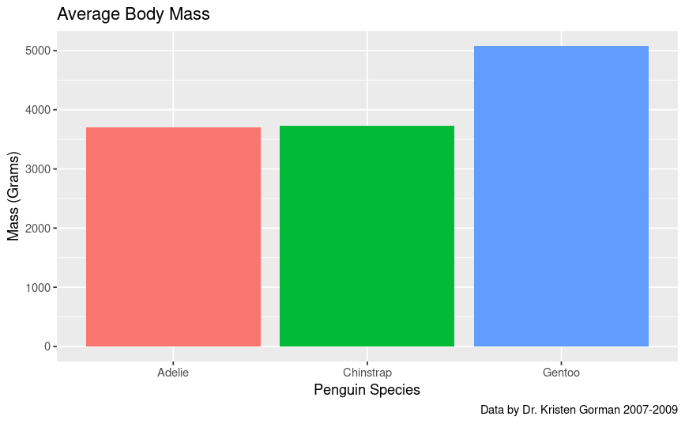